# Lighthouse Labs

## Multivariable Regression

As Sarah digs deeper into the data, she begins to wonder, "Is coffee the only thing driving productivity? Could there be other factors at play?" One day, after observing that some team members seemed especially sluggish despite their high coffee intake, Sarah realizes that sleep might also be a factor.

Sarah decides to test her hypothesis. In addition to tracking coffee consumption, she starts asking her team to report their hours of sleep each day. Over the next month, Sarah records this new variable.

After collecting enough data, Sarah now has three columns:

```
1. Coffee consumption (cups per day).
2. Hours of sleep (hours per night).
3. Productivity (number of tasks achieved in the day).
```

```python
df = pd.read_csv('data/coffee_productivity.csv')
df.head()
```

|  | Coffee_Cups | Hours_Sleep | Productivity |
| --- | --- | --- | --- |
| 0 | 7 | 7.605595 | 24.851737 |
| 1 | 4 | 6.963707 | 12.687456 |
| 2 | 8 | 5.644447 | 21.917630 |
| 3 | 5 | 7.486539 | 19.208558 |
| 4 | 7 | 5.231440 | 17.402905 |

```python
X = df.drop(columns=['Productivity'])
y = df['Productivity'].values
```

```python
X_train, X_test, y_train, y_test = train_test_split(X, y, test_size=0.2, random_state=42)
```

##### Additional step: Scale the data so that it is comparable.

```python
from sklearn.preprocessing import StandardScaler

scaler = StandardScaler()
X_train_scaled = scaler.fit_transform(X_train)
```

##### Important

**Never** do `.fit_transform()` on `test` data. **Always** use `.transform()` only.

```python
X_test_scaled = scaler.transform(X_test)
```

```python
lr = LinearRegression()
lr.fit(X_train_scaled, y_train)
```

```
LinearRegression()
```

```python
lr_coeffs = lr.coef_
lr_coeffs
```

```
array([6.4249594 , 2.09152413])
```

```python
lr_intercept = lr.intercept_
lr_intercept
```

```
np.float64(17.36193221782039)
```

```python
words_coeffs_df = pd.DataFrame(data = lr_coeffs.T, index = X_train.columns, columns=['Coefficients'])
words_coeffs_df
```

|  | Coefficients |
| --- | --- |
| Coffee_Cups | 6.424959 |
| Hours_Sleep | 2.091524 |

##### Why did we scale?

Sometimes variables are not really comparable. Scaling, allows us to put them in the same range. This allows us to be able to interpret the **coefficients** properly.

For interpreting linear models:

- if the coefficient is `+`, then if the feature value goes **UP** the predicted value goes **UP**
- if the coefficient is `-`, then if the feature values goes **UP** the predicted value goes **DOWN**
- if the coefficient is `0`, the feature is **not used** in making a prediction.

##### Prediction

```python
lr.predict(X_train_scaled)[:5]
```

```
array([15.53617259, 20.72490379, 28.2837986 , 10.5896231 , 27.82100943])
```

```python
lr.predict(X_test_scaled)[:5]
```

```
array([17.23753722, 28.37399184, 22.42152222, 26.65615455, 13.31313734])
```

```python
lr.intercept_ + (lr.coef_[0] * X_test_scaled[0][0]) + (lr.coef_[1] * X_test_scaled[0][1])
```

```
np.float64(17.237537221177554)
```

```python
lr.score(X_train_scaled, y_train)
```

```
0.9192148183081769
```

```python
lr.score(X_test_scaled, y_test)
```

```
0.9321424686508619
```

## Linear Regression with `statsmodels`

```python
import statsmodels.api as sm

model = sm.OLS(y_train, sm.add_constant(X_train_scaled))
results = model.fit()
```

```python
results.params
```

```
array([17.36193222,  6.4249594 ,  2.09152413])
```

```python
print(results.summary())
```

```
                            OLS Regression Results
==============================================================================
Dep. Variable:                      y   R-squared:                       0.919
Model:                            OLS   Adj. R-squared:                  0.919
Method:                 Least Squares   F-statistic:                     4534.
Date:                Tue, 22 Oct 2024   Prob (F-statistic):               0.00
Time:                        13:45:08   Log-Likelihood:                -1690.1
No. Observations:                 800   AIC:                             3386.
Df Residuals:                     797   BIC:                             3400.
Df Model:                           2
Covariance Type:            nonrobust
==============================================================================
                 coef    std err          t      P>|t|      [0.025      0.975]
------------------------------------------------------------------------------
const         17.3619      0.071    244.930      0.000      17.223      17.501
x1             6.4250      0.071     90.638      0.000       6.286       6.564
x2             2.0915      0.071     29.506      0.000       1.952       2.231
==============================================================================
Omnibus:                        0.145   Durbin-Watson:                   2.019
Prob(Omnibus):                  0.930   Jarque-Bera (JB):                0.143
Skew:                           0.032   Prob(JB):                        0.931
Kurtosis:                       2.989   Cond. No.                         1.00
==============================================================================

Notes:
[1] Standard Errors assume that the covariance matrix of the errors is correctly specified.
```

#### Score interpretation

- **R-squared** measures the proportion of the variation in your dependent variable (Y) explained by your independent variables (X) for a linear regression model
- **Adjusted R-squared** adjusts the statistic based on the number of independent variables in the model
- $R^2$ is a measure of fit.
- It indicates how much variation of a dependent variable is explained by the independent variables.
- An R-squared of 100% means that $y$ is completely explained by the independent variables.

$R^2 = 1 - \frac{Unexplained\:Variation}{Total\:Variation}$

$R^2 = 1 - \frac{RSS}{TSS}$

$R^2 = $ coefficient of determination  
$RSS = $ sum of squares of residuals $ =\displaystyle\sum_{i=1}^{n}(y_{i}-{\hat{y}_{i}})^{2}$  
$TSS = $ total sum of squares $ = \displaystyle\sum_{i=1}^{n}(y_{i}-\bar{y})^{2}$  
$\bar{y}$ = mean value

**Thus**,

$ R^2 = 1 - \frac{\displaystyle\sum_{i=1}^{n}(y_{i}-{\hat{y}_{i}})^{2}}{\displaystyle\sum_{i=1}^{n}(y_{i}-\bar{y})^{2}} $

### Going beyond linear regression: Polynomial regression

- **Linear regression** assumes a straight-line relationship between the variables.
- But what if the true relationship between the target (e.g., **productivity**) and the features (**coffee cups** and **hours of sleep**) is **non-linear**?
- Linear models can be limiting when the data follows a curve or more complex pattern.

#### Sarah's Coffee-Sleep-Productivity Example Revisited

- Sarah noticed that both **coffee** and **sleep** influence her team's productivity.
- However, as she collects more data, she realizes that **productivity doesn't increase linearly** with coffee or sleep.
- After a certain number of coffee cups, the productivity boost slows down.
- Too much or too little sleep seems to hurt productivity in a non-linear way.

#### What is Polynomial Regression?

- Polynomial regression extends linear regression by creating **quadratic, cubic, and higher-order terms**.
- We still use the **linear regression framework**, but we model more complex relationships by transforming the features.

#### Example:

- Instead of using just `Coffee_Cups`, we also use `Coffee_Cups^2`, `Coffee_Cups^3`, etc., to capture non-linear effects.

#### How Polynomial Regression Works:

- In addition to the original feature (`Coffee_Cups`), we create new features:
  - `Coffee_Cups^2`
  - `Coffee_Cups^3`
- These terms allow us to capture **curves** and more complex patterns.
- Our new model might look like: $$ \hat{y} = \beta_0 + \beta_1 x + \beta_2 x^2 + \beta_3 x^3 $$
- **Key Takeaway**: We can still use the linear regression framework by **transforming** our features into polynomial terms!

```python
from sklearn.preprocessing import PolynomialFeatures
```

```python
df = pd.read_csv('data/non_linear_coffee_productivity.csv')
df.head(2)
```

|  | Coffee_Cups | Hours_Sleep | Productivity |
| --- | --- | --- | --- |
| 0 | 3 | 9.055615 | 11.421316 |
| 1 | 2 | 9.144187 | 6.674547 |

```python
X = df.drop(columns=['Productivity'])
y = df['Productivity']
```

```python
X_train, X_test, y_train, y_test = train_test_split(X, y, test_size=0.2, random_state=42)
```

```python
# Create polynomial features (degree 2)
poly = PolynomialFeatures(degree=2)
X_poly_train = poly.fit_transform(X_train)

# Fit the polynomial regression model
model = LinearRegression()
model.fit(X_poly_train, y_train)
```

```
LinearRegression()
```

```python
y_pred = model.predict(X_poly_train)
```

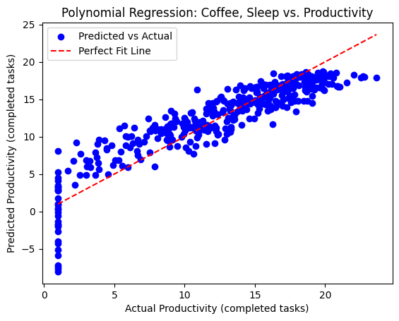

```python
# We'll plot only the actual vs predicted productivity
plt.scatter(y_train, y_pred, color='blue', label='Predicted vs Actual')
plt.plot([min(y_train), max(y_train)], [min(y_train), max(y_train)], color='red', linestyle='--', label='Perfect Fit Line')
plt.xlabel('Actual Productivity (completed tasks)')
plt.ylabel('Predicted Productivity (completed tasks)')
plt.title('Polynomial Regression: Coffee, Sleep vs. Productivity')
plt.legend()
plt.show()
```

```python
import plotly.graph_objects as go
import plotly.io as pio
pio.renderers.default = 'iframe'

scatter = go.Scatter3d(
    x=X_train['Coffee_Cups'],
    y=X_train['Hours_Sleep'],
    z=y_train,
    mode='markers',
    marker=dict(size=5, color='blue', opacity=0.8),
    name='Data'
)

surface = go.Mesh3d(
    x=X_train['Coffee_Cups'],
    y=X_train['Hours_Sleep'],
    z=y_pred,
    opacity=0.6,
    color='red',
    name='Polynomial Fit'
)

layout = go.Layout(
    title='Polynomial Regression: Coffee, Sleep vs. Productivity',
    scene=dict(
        xaxis_title='Cups of Coffee',
        yaxis_title='Hours of Sleep',
        zaxis_title='Productivity (completed tasks)',
        aspectratio=dict(x=1, y=1, z=1)
    )
)

fig = go.Figure(data=[scatter, surface], layout=layout)
fig.show()
```

[interactive chart not shown]

What `sklearn` does is - if you substitute $x^2$ as another variable such as `m`, then the equation now is:

`y=w*m + b`

The relation between `y` and `m` is linear but it is not linear between `x` and `y`.

Because of this "technically", it is linear regression just the variables between which it happens is $x^2$ (`m`) and `y` and not `x` and `y`.